# CIS 435 - Module 3 - Sample Example - Supervised Learning with Classification

```python
#Import Python libraries

import pandas as pd
import numpy as np
import matplotlib.pyplot as plt
%matplotlib inline
import seaborn as sns
from sklearn.neighbors import KNeighborsClassifier
from sklearn.tree import DecisionTreeClassifier
from sklearn.linear_model import LogisticRegression
from sklearn.ensemble import RandomForestClassifier
from sklearn import metrics
```

```python
#Import and visualize dataset

data = pd.read_csv('bdata.csv')
print(data.columns)
print("dimension of data: {}".format(data.shape))

#No nulls and nothing out of the ordinary with info() results
data.info()
data.head()

# , 'area_mean', 'smoothness_mean', 'compactness_mean'
X = data[['radius_mean', 'texture_mean', 'perimeter_mean', 'area_mean',
       'smoothness_mean', 'compactness_mean', 'concavity_mean',
       'concave points_mean', 'symmetry_mean', 'fractal_dimension_mean',
       'radius_se', 'texture_se', 'perimeter_se', 'area_se', 'smoothness_se',
       'compactness_se', 'concavity_se', 'concave points_se', 'symmetry_se',
       'fractal_dimension_se']]
y = data['diagnosis']

data.describe()
```

```
Index(['id', 'radius_mean', 'texture_mean', 'perimeter_mean', 'area_mean',
       'smoothness_mean', 'compactness_mean', 'concavity_mean',
       'concave points_mean', 'symmetry_mean', 'fractal_dimension_mean',
       'radius_se', 'texture_se', 'perimeter_se', 'area_se', 'smoothness_se',
       'compactness_se', 'concavity_se', 'concave points_se', 'symmetry_se',
       'fractal_dimension_se', 'radius_worst', 'diagnosis'],
      dtype='object')
dimension of data: (569, 23)
<class 'pandas.core.frame.DataFrame'>
RangeIndex: 569 entries, 0 to 568
Data columns (total 23 columns):
 #   Column                  Non-Null Count  Dtype
---  ------                  --------------  -----
 0   id                      569 non-null    int64
 1   radius_mean             569 non-null    float64
 2   texture_mean            569 non-null    float64
 3   perimeter_mean          569 non-null    float64
 4   area_mean               569 non-null    float64
 5   smoothness_mean         569 non-null    float64
 6   compactness_mean        569 non-null    float64
 7   concavity_mean          569 non-null    float64
 8   concave points_mean     569 non-null    float64
 9   symmetry_mean           569 non-null    float64
 10  fractal_dimension_mean  569 non-null    float64
 11  radius_se               569 non-null    float64
 12  texture_se              569 non-null    float64
 13  perimeter_se            569 non-null    float64
 14  area_se                 569 non-null    float64
 15  smoothness_se           569 non-null    float64
 16  compactness_se          569 non-null    float64
 17  concavity_se            569 non-null    float64
 18  concave points_se       569 non-null    float64
 19  symmetry_se             569 non-null    float64
 20  fractal_dimension_se    569 non-null    float64
 21  radius_worst            569 non-null    float64
 22  diagnosis               569 non-null    int64
dtypes: float64(21), int64(2)
memory usage: 102.4 KB
```

|  | id | radius_mean | texture_mean | perimeter_mean | area_mean | smoothness_mean | compactness_mean | concavity_mean | concave points_mean | symmetry_mean | ... | perimeter_se | area_se | smoothness_se | compactness_se | concavity_se | concave points_se | symmetry_se | fractal_dimension_se | radius_worst | diagnosis |
| --- | --- | --- | --- | --- | --- | --- | --- | --- | --- | --- | --- | --- | --- | --- | --- | --- | --- | --- | --- | --- | --- |
| count | 5.690000e+02 | 569.000000 | 569.000000 | 569.000000 | 569.000000 | 569.000000 | 569.000000 | 569.000000 | 569.000000 | 569.000000 | ... | 569.000000 | 569.000000 | 569.000000 | 569.000000 | 569.000000 | 569.000000 | 569.000000 | 569.000000 | 569.000000 | 569.000000 |
| mean | 3.037183e+07 | 14.127292 | 19.289649 | 91.969033 | 654.889104 | 0.096360 | 0.104341 | 0.088799 | 0.048919 | 0.181162 | ... | 2.866059 | 40.337079 | 0.007041 | 0.025478 | 0.031894 | 0.011796 | 0.020542 | 0.003795 | 16.269190 | 0.372583 |
| std | 1.250206e+08 | 3.524049 | 4.301036 | 24.298981 | 351.914129 | 0.014064 | 0.052813 | 0.079720 | 0.038803 | 0.027414 | ... | 2.021855 | 45.491006 | 0.003003 | 0.017908 | 0.030186 | 0.006170 | 0.008266 | 0.002646 | 4.833242 | 0.483918 |
| min | 8.670000e+03 | 6.981000 | 9.710000 | 43.790000 | 143.500000 | 0.052630 | 0.019380 | 0.000000 | 0.000000 | 0.106000 | ... | 0.757000 | 6.802000 | 0.001713 | 0.002252 | 0.000000 | 0.000000 | 0.007882 | 0.000895 | 7.930000 | 0.000000 |
| 25% | 8.692180e+05 | 11.700000 | 16.170000 | 75.170000 | 420.300000 | 0.086370 | 0.064920 | 0.029560 | 0.020310 | 0.161900 | ... | 1.606000 | 17.850000 | 0.005169 | 0.013080 | 0.015090 | 0.007638 | 0.015160 | 0.002248 | 13.010000 | 0.000000 |
| 50% | 9.060240e+05 | 13.370000 | 18.840000 | 86.240000 | 551.100000 | 0.095870 | 0.092630 | 0.061540 | 0.033500 | 0.179200 | ... | 2.287000 | 24.530000 | 0.006380 | 0.020450 | 0.025890 | 0.010930 | 0.018730 | 0.003187 | 14.970000 | 0.000000 |
| 75% | 8.813129e+06 | 15.780000 | 21.800000 | 104.100000 | 782.700000 | 0.105300 | 0.130400 | 0.130700 | 0.074000 | 0.195700 | ... | 3.357000 | 45.190000 | 0.008146 | 0.032450 | 0.042050 | 0.014710 | 0.023480 | 0.004558 | 18.790000 | 1.000000 |
| max | 9.113205e+08 | 28.110000 | 39.280000 | 188.500000 | 2501.000000 | 0.163400 | 0.345400 | 0.426800 | 0.201200 | 0.304000 | ... | 21.980000 | 542.200000 | 0.031130 | 0.135400 | 0.396000 | 0.052790 | 0.078950 | 0.029840 | 36.040000 | 1.000000 |

8 rows × 23 columns

```python
#Ensure data does not contain blanks
data.isnull().any()
```

```
id                        False
radius_mean               False
texture_mean              False
perimeter_mean            False
area_mean                 False
smoothness_mean           False
compactness_mean          False
concavity_mean            False
concave points_mean       False
symmetry_mean             False
fractal_dimension_mean    False
radius_se                 False
texture_se                False
perimeter_se              False
area_se                   False
smoothness_se             False
compactness_se            False
concavity_se              False
concave points_se         False
symmetry_se               False
fractal_dimension_se      False
radius_worst              False
diagnosis                 False
dtype: bool
```

```python
#Create training set for supervised learning models
from sklearn.model_selection import train_test_split
X_train, X_test, y_train, y_test = train_test_split(X, y, random_state=1)
```

### Logistic Regression

Logistic regression is one of the most common classification algorithms.

```
Training set accuracy: 0.9272
Test set accuracy: 0.8881
Feature importances:

                        Importance
radius_mean              -1.222638
texture_mean              0.282034
perimeter_mean            0.587227
area_mean                -0.022015
smoothness_mean           0.203300
compactness_mean          0.351692
concavity_mean            0.731230
concave points_mean       0.328134
symmetry_mean             0.369454
fractal_dimension_mean    0.050714
radius_se                -0.205358
texture_se               -0.931213
perimeter_se             -0.438115
area_se                   0.108678
smoothness_se             0.000699
compactness_se           -0.090070
concavity_se             -0.031033
concave points_se        -0.006046
symmetry_se              -0.029366
fractal_dimension_se     -0.024401

Confusion Matrix:
[[80  8]
 [ 8 47]]
              precision    recall  f1-score   support

           0       0.91      0.91      0.91        88
           1       0.85      0.85      0.85        55

    accuracy                           0.89       143
   macro avg       0.88      0.88      0.88       143
weighted avg       0.89      0.89      0.89       143
```

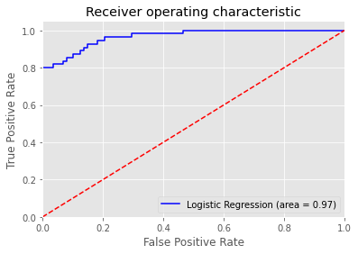

```
AUC: 0.967
```

```python
#Increased iteration amount
#First lets use Logistic Regression to determine which features are highest value
logreg = LogisticRegression(solver='lbfgs', max_iter=1000).fit(X_train, y_train)
print("Training set accuracy: {:.4f}".format(logreg.score(X_train, y_train)))
print("Test set accuracy: {:.4f}".format(logreg.score(X_test, y_test)))

logreg.coef_.T

print("Feature importances:\n")
#Using this code to determine importance of each feature
importantDF = pd.DataFrame(logreg.coef_.T, X.columns)
print(importantDF.rename(columns={0:"Importance"}))


#Confusion Matrix
print("\nConfusion Matrix:")
y_pred = logreg.predict(X_test)
from sklearn.metrics import confusion_matrix
confusion_matrix = confusion_matrix(y_test, y_pred)
print(confusion_matrix)

# Precision/Recall
from sklearn.metrics import classification_report
print(classification_report(y_test, y_pred))

#ROC curve
from sklearn.metrics import roc_auc_score
from sklearn.metrics import roc_curve
logit_roc_auc = roc_auc_score(y_test, logreg.predict(X_test))
fpr, tpr, thresholds = roc_curve(y_test, logreg.predict_proba(X_test)[:,1])
plt.figure()
plt.plot(fpr, tpr, 'b',label='Logistic Regression (area = %0.2f)' % metrics.auc(fpr, tpr) )
plt.plot([0, 1], [0, 1],'r--')
plt.xlim([0.0, 1.0])
plt.ylim([0.0, 1.05])
plt.xlabel('False Positive Rate')
plt.ylabel('True Positive Rate')
plt.title('Receiver operating characteristic')
plt.legend(loc="lower right")
plt.savefig('Log_ROC')
plt.show()

# calculate AUC

print('AUC: %.3f' % metrics.auc(fpr, tpr))
```

### Naive Bayes

```
Accuracy on training set: 0.9108
Accuracy on test set: 0.9231
[[86  2]
 [ 9 46]]
              precision    recall  f1-score   support

           0       0.91      0.98      0.94        88
           1       0.96      0.84      0.89        55

    accuracy                           0.92       143
   macro avg       0.93      0.91      0.92       143
weighted avg       0.93      0.92      0.92       143
```

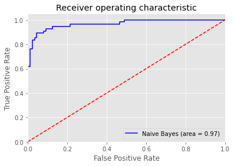

```
AUC: 0.968
```

```python
from sklearn.naive_bayes import GaussianNB
gnb = GaussianNB()
gnb.fit(X_train, y_train)

print("Accuracy on training set: {:.4f}".format(gnb.score(X_train, y_train)))
print("Accuracy on test set: {:.4f}".format(gnb.score(X_test, y_test)))


#Confusion Matrix
y_pred = gnb.predict(X_test)
from sklearn.metrics import confusion_matrix
confusion_matrix = confusion_matrix(y_test, y_pred)
print(confusion_matrix)

#Precision/Recall
from sklearn.metrics import classification_report
print(classification_report(y_test, y_pred))

#ROC Curve
from sklearn.metrics import roc_auc_score
from sklearn.metrics import roc_curve
GNB_roc_auc = roc_auc_score(y_test, gnb.predict(X_test))
fpr, tpr, thresholds = roc_curve(y_test, gnb.predict_proba(X_test)[:,1])
plt.figure()
plt.plot(fpr, tpr, 'b', label='Naive Bayes (area = %0.2f)' % metrics.auc(fpr, tpr))
plt.plot([0, 1], [0, 1],'r--')
plt.xlim([0.0, 1.0])
plt.ylim([0.0, 1.05])
plt.xlabel('False Positive Rate')
plt.ylabel('True Positive Rate')
plt.title('Receiver operating characteristic')
plt.legend(loc="lower right")
plt.savefig('GNB_ROC')
plt.show()

# calculate AUC

print('AUC: %.3f' % metrics.auc(fpr, tpr))
```

### Decision Tree

```
Accuracy on training set: 0.9836
Accuracy on test set: 0.9371
Feature importances:
                        Importance
radius_mean               0.035544
texture_mean              0.096387
perimeter_mean            0.023771
area_mean                 0.000000
smoothness_mean           0.000000
compactness_mean          0.000000
concavity_mean            0.027764
concave points_mean       0.753307
symmetry_mean             0.000000
fractal_dimension_mean    0.000000
radius_se                 0.000000
texture_se                0.000000
perimeter_se              0.000000
area_se                   0.015177
smoothness_se             0.000000
compactness_se            0.000000
concavity_se              0.000000
concave points_se         0.000000
symmetry_se               0.027536
fractal_dimension_se      0.020515
[[85  3]
 [ 6 49]]
              precision    recall  f1-score   support

           0       0.93      0.97      0.95        88
           1       0.94      0.89      0.92        55

    accuracy                           0.94       143
   macro avg       0.94      0.93      0.93       143
weighted avg       0.94      0.94      0.94       143
```

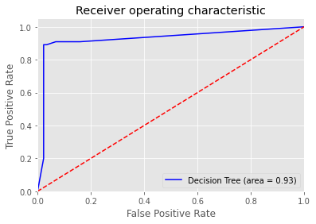

```
AUC: 0.928
```

```python
tree = DecisionTreeClassifier(max_depth=4,random_state=0)
tree.fit(X_train, y_train)
print("Accuracy on training set: {:.4f}".format(tree.score(X_train, y_train)))
print("Accuracy on test set: {:.4f}".format(tree.score(X_test, y_test)))

#Feature importance rates how important each feature is for the decision a tree makes. It is a number between 0 and 1 for each feature, where 0 means “not used at all” and 1 means “perfectly predicts the target.”
#The feature importances always sum to 1

importantDF = pd.DataFrame(tree.feature_importances_, X.columns)
print(f'Feature importances:\n{importantDF.rename(columns={0:"Importance"})}')

#Confusion Matrix
y_pred = tree.predict(X_test)
from sklearn.metrics import confusion_matrix
confusion_matrix = confusion_matrix(y_test, y_pred)
print(confusion_matrix)

# Precision/Recall
from sklearn.metrics import classification_report
print(classification_report(y_test, y_pred))

from sklearn.metrics import roc_auc_score
from sklearn.metrics import roc_curve
DT_roc_auc = roc_auc_score(y_test, tree.predict(X_test))
fpr, tpr, thresholds = roc_curve(y_test, tree.predict_proba(X_test)[:,1])
plt.figure()
plt.plot(fpr, tpr, 'b', label='Decision Tree (area = %0.2f)' % metrics.auc(fpr, tpr))
plt.plot([0, 1], [0, 1],'r--')
plt.xlim([0.0, 1.0])
plt.ylim([0.0, 1.05])
plt.xlabel('False Positive Rate')
plt.ylabel('True Positive Rate')
plt.title('Receiver operating characteristic')
plt.legend(loc="lower right")
plt.savefig('DT_ROC')
plt.show()

# calculate AUC

print('AUC: %.3f' % metrics.auc(fpr, tpr))
```

### K Means

```python
from copy import deepcopy
plt.rcParams['figure.figsize'] = (16, 9)
plt.style.use('ggplot')
```

```python
# Getting the values and plotting it
f1 = data['diagnosis'].values
f2 = data['radius_mean'].values
f3 = data['texture_mean'].values
f4 = data['perimeter_mean'].values
f5 = data['area_mean'].values
f6 = data['smoothness_mean'].values
f7 = data['compactness_mean'].values
f8 = data['concavity_mean'].values
f9 = data['concave points_mean'].values
f10 = data['symmetry_mean'].values
f11 = data['id'].values




X = np.array(list(zip(f7, f2, f3, f4, f10)))
```

```python
from sklearn.cluster import KMeans

# Number of clusters
kmeans = KMeans(n_clusters=2)
# Fitting the input data
kmeans = kmeans.fit(X)
# Getting the cluster labels
labels = kmeans.predict(X)
# Centroid values
centroids = kmeans.cluster_centers_

labels = kmeans.labels_
```

```python
# Comparing with scikit-learn centroids

print(centroids)
```

```
[[8.86847596e-02 1.23636274e+01 1.84194712e+01 7.97643750e+01
  1.77417788e-01]
 [1.46909542e-01 1.89226144e+01 2.16556209e+01 1.25152941e+02
  1.91341830e-01]]
```

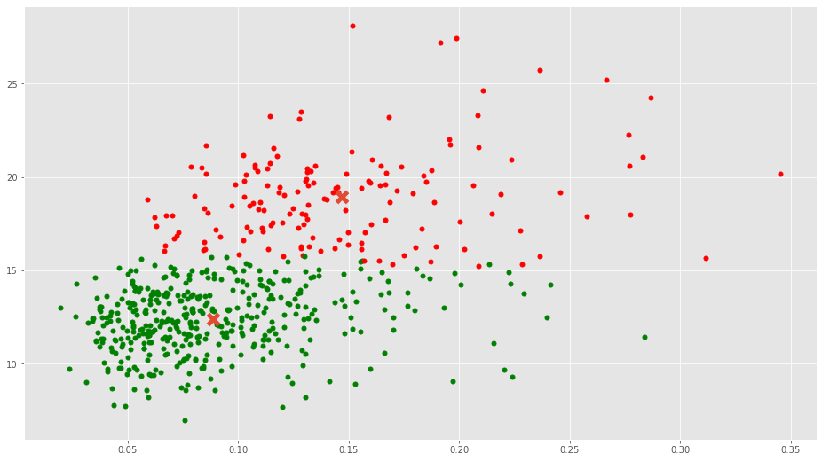

```python
#displaying plot of centroids

colors = ["g.","r.","c.","y."]

for i in range(len(X)):
    #print("coordinate:",X[i], "label:", labels[i])
    plt.plot(X[i][0], X[i][1], colors[labels[i]], markersize = 10)



plt.scatter(centroids[:, 0],centroids[:, 1], marker = "x", s=150, linewidths = 5, zorder = 10)

plt.show()
```

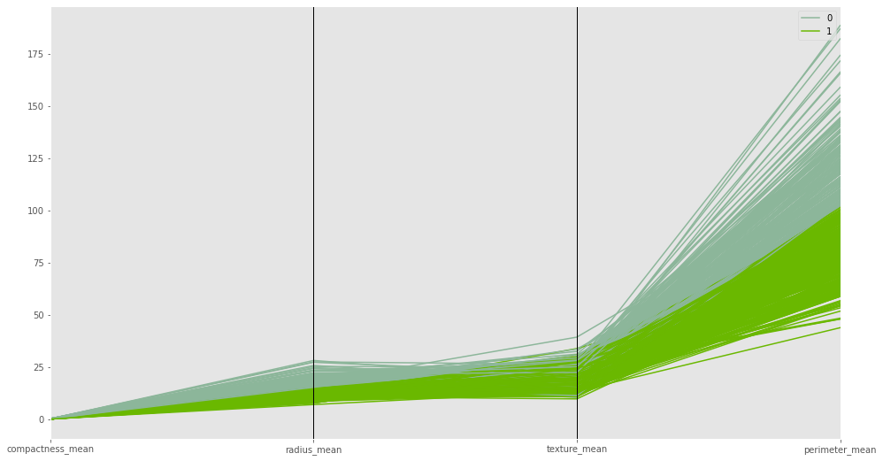

```python
predict = kmeans.predict(X)
data['cluster'] = predict

pd.plotting.parallel_coordinates(data[['compactness_mean', 'radius_mean', 'texture_mean'
                                       , 'perimeter_mean', 'cluster']], 'cluster')
```

Business Problem: The goal of this assignment is to accurately predict whether a patients breast cancer tumor is malignant or benign. With this second opinion, doctors can better server our community by treating patients who have malignant tumors. The model should assist doctors in determining whether treatment is needed based on tumor classification.

Machine Learning Applications: Using a Naive Bayes to read chest X-Rays to determine if a patient has COVID, pneumonia, or normal scans. Second example is using K-Means clustering to read Alzheimer's patient data to search for commonalities between patients. Third example is using logistic regression to classify a patient's diabetes as type 1 or 2.

Machine Learning Algorithms: Naive Bayes: Using Bayes' Theorem, we can determine which class an object belongs to and use its features to predict future objects. Naive Bayes also assumes that all attributes of a data record are independent. This algorithm is great for its speed and ability to slice through high dimensions of data like text and email. Unfortunately, assuming all attributes are independent is not something that happens often in real life scenarios.

Logistic Regression: Logistic regression differs from linear regression in a few ways. Linear regression can be used to predict any values along a straight line, however, logistic regression tries to predict values between 0 and 1. As such, we use Logistic regression for classification problems where we are trying to determine 0 and 1. Using thresholds, we can determine the class an object can fall into. Just like Naive Bayes, Linear regression is simple and can provide results with great speed and limited processing powers. Unfortunately, Linear regression requires a large focus on data quality and ensuring no missing values exist in the dataset. The algorithm does not handle missing data very well.

Decision Trees: The goal of a decision tree algorithm is to predict the value of a target variable by learning simple decision rules inferred from the data features. The tree portion is the different questions or qualifications that lead you to a corresponding leaf. The leaf is the classification outcome expected from the model. Decision trees are very simple and easy to understand, however they are not very stable as any change to the data can cause negative impacts to the model.

K-Means: A K-Means model uses the sum of squares to group data into centroids. The model will work to group simliar datapoints together and point out patterns. Simple, flexible and great for a large dataset. However, it is memory intensive and requires a lot of computing resources.

Explaining Metrics: In the metrics section, I was mostly focused on ensuring we looked at each of the features. Understanding their importance is key in understanding how the model is functioning with the data. I used importance scores to rank each of the features.

Recommended Steps: The first step in optimizing performance, in my opinion, would be to use the feature importance values calculated in the explain metrics section to limit the amount of features fed to the model. Next, I would tune the models to ensure we had virtually 0 false negatives to ensure patient safety.

```python
#  The code below can be added to the logistic regression (but can be adjusted to any of the supervised algorithms)
#  to remove the features that have a negative or 0 importance score.


# #only keeping positive and greater than 0 value features
# finaldf = tempdf[tempdf[0]>0]
# print(f'\nFinal set of features: \n {finaldf}')

# #cleaning up the dataframe, ensuring we reassign X to only our new values
# finaldf.reset_index(inplace=True)
# finaldf.rename(columns={'index':'Field Name', 0:'Value'}, inplace = True)
# X = data[finaldf['Field Name'].values]

# #reset training data and log regression model (sub model out for any supervised learning model above)
# X_train, X_test, y_train, y_test = train_test_split(X, y, random_state=1)
# logreg = LogisticRegression(solver='lbfgs', max_iter=1000).fit(X_train, y_train)
# print("\nTraining set accuracy: {:.4f}".format(logreg.score(X_train, y_train)))
# print("Test set accuracy: {:.4f}".format(logreg.score(X_test, y_test)))

# #checking feature fit now
# print(f'\nNew Feature Fit:\n {pd.DataFrame(logreg.coef_.T, X.columns)}')
```